# Elsevier 2022 SDG mapping

# General to all SDGs

## Introduction

The United Nations Sustainable Development Goals (SDGs) challenge the global community to build a world where no one is left behind.

Since 2018, Elsevier has generated SDG search queries to help researchers and institutions track and demonstrate progress toward the SDG targets. In the past 3 years, these queries, along with the university’s own data and evidence supporting progress and contributions to the particular SDG outside of research-based metrics, are used for the THE Impact Rankings.

## Method

For 2022, this SDG uses the exact same search query and ML algorithm as the Elsevier 2021 SDG mapping. [Full details of the 2021 methodology are available on Digital Commons Data.](https://elsevier.digitalcommonsdata.com/datasets/9sxdykm8s4/4)

# [SDG 4 - Ensure inclusive and equitable quality education and promote lifelong learning opportunities for all](https://sdgs.un.org/goals/goal4)

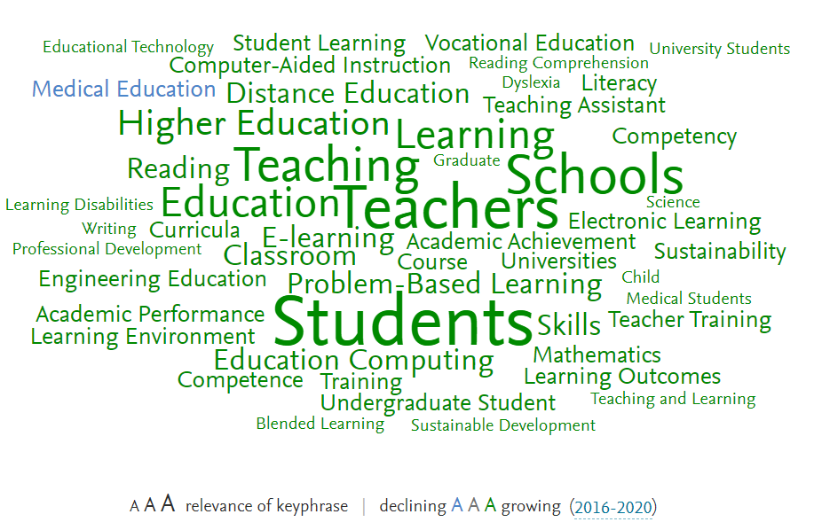

Explore this wordcloud plus the most active contributors on the [SciVal SDG site](https://scival.com/sdg)

## Query

Below is the full search query used for this SDG. We’ve broken it down by each query component. Use the + and – to concatenate the different bracket levels.

(

(

(

(

((TITLE-ABS("school") OR TITLE-ABS("student*")) AND TITLE-ABS("internet-based learning environment")) OR ((TITLE-ABS("school") OR TITLE-ABS("student*")) AND TITLE-ABS("internetbased learning environment"))

)

OR

(

((AUTHKEY("school") OR AUTHKEY("student*")) AND AUTHKEY("internet-based learning environment")) OR ((AUTHKEY("school") OR AUTHKEY("student*")) AND AUTHKEY("internetbased learning environment"))

)

OR

(

TITLE-ABS("web*-based* learning* system*") OR TITLE-ABS("webbased* learning* system*")

)

OR

(

AUTHKEY("web*-based* learning* system*") OR AUTHKEY("webbased* learning* system*")

)

OR

(

TITLE-ABS("child-friendly schools") OR TITLE-ABS("childfriendly schools")

)

OR

(

AUTHKEY("child-friendly schools") OR AUTHKEY("childfriendly schools")

)

OR

(

(TITLE-ABS("school") OR TITLE-ABS("schools")) AND (TITLE-ABS("drinking water") OR TITLE-ABS("sanitation") OR TITLE-ABS("handwashing") OR TITLE-ABS("hand washing"))

)

OR

(

(AUTHKEY("school") OR AUTHKEY("schools")) AND (AUTHKEY("drinking water") OR AUTHKEY("sanitation") OR AUTHKEY("handwashing") OR AUTHKEY("hand washing"))

)

OR TITLE-ABS

(

"ubiquitous learning"

)

OR AUTHKEY

(

"ubiquitous learning"

)

OR

(

TITLE-ABS("school construction") OR TITLE-ABS("school renovation")

)

OR

(

AUTHKEY("school construction") OR AUTHKEY("school renovation")

)

OR

(

TITLE-ABS("course* material*") AND (TITLE-ABS("disabled") OR TITLE-ABS("disabilit*"))

)

OR

(

AUTHKEY("course* material*") AND (AUTHKEY("disabled") OR AUTHKEY("disabilit*"))

)

OR

(

TITLE-ABS("education* facilit* design*") OR TITLE-ABS("education* facilit*")

)

OR

(

AUTHKEY("education* facilit* design*") OR AUTHKEY("education* facilit*")

)

OR TITLE-ABS

(

"educational infrastructure"

)

OR AUTHKEY

(

"educational infrastructure"

)

OR TITLE-ABS

(

"school ventilation"

)

OR AUTHKEY

(

"school ventilation"

)

OR

(

(TITLE-ABS("e-learning platform") OR TITLE-ABS("e-learning platforms")) OR (TITLE-ABS("elearning platform") OR TITLE-ABS("elearning platforms"))

)

OR

(

(AUTHKEY("e-learning platform") OR AUTHKEY("e-learning platforms")) OR (AUTHKEY("elearning platform") OR AUTHKEY("elearning platforms"))

)

OR

(

(TITLE-ABS("school") OR TITLE-ABS("education")) AND (TITLE-ABS("access to internet") OR TITLE-ABS("access to changing technology") OR TITLE-ABS("access* to* technology* material*"))

)

OR

(

(AUTHKEY("school") OR AUTHKEY("education")) AND (AUTHKEY("access to internet") OR AUTHKEY("access to changing technology") OR AUTHKEY("access* to* technology* material*"))

)

OR

(

(TITLE-ABS("multimedia") OR TITLE-ABS("hypermedia")) AND TITLE-ABS("system") AND TITLE-ABS("education")

)

OR

(

(AUTHKEY("multimedia") OR AUTHKEY("hypermedia")) AND AUTHKEY("system") AND AUTHKEY("education")

)

OR TITLE-ABS

(

"effective* learning* environment*"

)

OR AUTHKEY

(

"effective* learning* environment*"

)

OR TITLE-ABS

(

"school* building*"

)

OR AUTHKEY

(

"school* building*"

)

OR TITLE-ABS

(

"safety in school"

)

OR AUTHKEY

(

"safety in school"

)

OR TITLE-ABS

(

"education* hypermedia*"

)

OR AUTHKEY

(

"education* hypermedia*"

)

OR

(

TITLE-ABS("student*") AND (TITLE-ABS("disabled") OR TITLE-ABS("disabilit*")) AND TITLE-ABS("barrier*")

)

OR

(

AUTHKEY("student*") AND (AUTHKEY("disabled") OR AUTHKEY("disabilit*")) AND AUTHKEY("barrier*")

)

OR

(

TITLE-ABS("learning* environment*") AND (TITLE-ABS("improve") OR TITLE-ABS("better") OR TITLE-ABS("facilitate")) AND (TITLE-ABS("material") OR TITLE-ABS("tool") OR TITLE-ABS("tools") OR TITLE-ABS("infrastructure"))

)

OR

(

AUTHKEY("learning* environment*") AND (AUTHKEY("improve") OR AUTHKEY("better") OR AUTHKEY("facilitate")) AND (AUTHKEY("material") OR AUTHKEY("tool") OR AUTHKEY("tools") OR AUTHKEY("infrastructure"))

)

OR

(

TITLE-ABS("Educational technology ") AND (TITLE-ABS("rural") OR TITLE-ABS("increased access") OR TITLE-ABS("disabled") OR TITLE-ABS("disabilit*") OR TITLE-ABS("gender") OR TITLE-ABS("inclusive"))

)

OR

(

AUTHKEY("Educational technology ") AND (AUTHKEY("rural") OR AUTHKEY("increased access") OR AUTHKEY("disabled") OR AUTHKEY("disabilit*") OR AUTHKEY("gender") OR AUTHKEY("inclusive"))

)

OR TITLE-ABS

(

"universal design for learning"

)

OR AUTHKEY

(

"universal design for learning"

)

OR TITLE-ABS

(

"learning* infrastructure*"

)

OR AUTHKEY

(

"learning* infrastructure*"

)

OR

(

TITLE-ABS("Indoor* environment* quality*") AND (TITLE-ABS("school*") OR TITLE-ABS("college*") OR TITLE-ABS("classroom*"))

)

OR

(

AUTHKEY("Indoor* environment* quality*") AND (AUTHKEY("school*") OR AUTHKEY("college*") OR AUTHKEY("classroom*"))

)

OR

(

(TITLE-ABS("child*") OR TITLE-ABS("student") OR TITLE-ABS("people")) AND (TITLE-ABS("disabled") OR TITLE-ABS("disabilit*")) AND (TITLE-ABS("school") OR TITLE-ABS("learning")) AND (TITLE-ABS("environment") OR TITLE-ABS("access"))

)

OR

(

(AUTHKEY("child*") OR AUTHKEY("student") OR AUTHKEY("people")) AND (AUTHKEY("disabled") OR AUTHKEY("disabilit*")) AND (AUTHKEY("school") OR AUTHKEY("learning")) AND (AUTHKEY("environment") OR AUTHKEY("access"))

)

OR TITLE-ABS

(

"asynchronous* learning* system*"

)

OR AUTHKEY

(

"asynchronous* learning* system*"

)

OR

(

TITLE-ABS("distance learning") OR TITLE-ABS("distance education")

)

OR

(

AUTHKEY("distance learning") OR AUTHKEY("distance education")

)

OR TITLE-ABS

(

"learning* assistance* tool*"

)

OR AUTHKEY

(

"learning* assistance* tool*"

)

OR TITLE-ABS

(

"education* building*"

)

OR AUTHKEY

(

"education* building*"

)

OR TITLE-ABS

(

"school* facilit*"

)

OR AUTHKEY

(

"school* facilit*"

)

OR

(

TITLE-ABS("remote experimentation") AND (TITLE-ABS("school") OR TITLE-ABS("education") OR TITLE-ABS("student") OR TITLE-ABS("learning")) AND (TITLE-ABS("increased access") OR TITLE-ABS("disabled") OR TITLE-ABS("disabilit*") OR TITLE-ABS("gender") OR TITLE-ABS("inclusive"))

)

OR

(

AUTHKEY("remote experimentation") AND (AUTHKEY("school") OR AUTHKEY("education") OR AUTHKEY("student") OR AUTHKEY("learning")) AND (AUTHKEY("increased access") OR AUTHKEY("disabled") OR AUTHKEY("disabilit*") OR AUTHKEY("gender") OR AUTHKEY("inclusive"))

)

OR

(

TITLE-ABS("Indoor* air* quality*") AND (TITLE-ABS("school*") OR TITLE-ABS("college*") OR TITLE-ABS("classroom*"))

)

OR

(

AUTHKEY("Indoor* air* quality*") AND (AUTHKEY("school*") OR AUTHKEY("college*") OR AUTHKEY("classroom*"))

)

OR

(

TITLE-ABS("tele-learning") OR TITLE-ABS("telelearning")

)

OR

(

AUTHKEY("tele-learning") OR AUTHKEY("telelearning")

)

OR

(

TITLE-ABS("Learning tools ") AND (TITLE-ABS("rural") OR TITLE-ABS("increased access") OR TITLE-ABS("disabled") OR TITLE-ABS("disabilit*") OR TITLE-ABS("gender") OR TITLE-ABS("inclusive"))

)

OR

(

AUTHKEY("Learning tools ") AND (AUTHKEY("rural") OR AUTHKEY("increased access") OR AUTHKEY("disabled") OR AUTHKEY("disabilit*") OR AUTHKEY("gender") OR AUTHKEY("inclusive"))

)

OR

(

(TITLE-ABS("school") OR TITLE-ABS("schools")) AND TITLE-ABS("potable") AND TITLE-ABS("water")

)

OR

(

(AUTHKEY("school") OR AUTHKEY("schools")) AND AUTHKEY("potable") AND AUTHKEY("water")

)

OR TITLE-ABS

(

"virtual* learning* environment*"

)

OR AUTHKEY

(

"virtual* learning* environment*"

)

OR

(

TITLE-ABS("communication* technolog*") AND TITLE-ABS("improved learning ") AND (TITLE-ABS("student*") OR TITLE-ABS("school*"))

)

OR

(

AUTHKEY("communication* technolog*") AND AUTHKEY("improved learning ") AND (AUTHKEY("student*") OR AUTHKEY("school*"))

)

OR

(

(TITLE-ABS("universit*") OR TITLE-ABS("educational* institution*") OR TITLE-ABS("school") OR TITLE-ABS("schools") OR TITLE-ABS("academic* institution*")) AND (TITLE-ABS("quality") OR TITLE-ABS("adequacy") OR TITLE-ABS("inadequacy") OR TITLE-ABS("appropriateness")) AND TITLE-ABS("teaching material")

)

OR

(

(AUTHKEY("universit*") OR AUTHKEY("educational* institution*") OR AUTHKEY("school") OR AUTHKEY("schools") OR AUTHKEY("academic* institution*")) AND (AUTHKEY("quality") OR AUTHKEY("adequacy") OR AUTHKEY("inadequacy") OR AUTHKEY("appropriateness")) AND AUTHKEY("teaching material")

)

OR

(

TITLE-ABS("school design") OR TITLE-ABS("school designs")

)

OR

(

AUTHKEY("school design") OR AUTHKEY("school designs")

)

OR

(

TITLE-ABS("tobacco-free education") OR TITLE-ABS("tobaccofree education")

)

OR

(

AUTHKEY("tobacco-free education") OR AUTHKEY("tobaccofree education")

)

OR

(

(TITLE-ABS("e-learning system") OR TITLE-ABS("e-learning systems")) OR (TITLE-ABS("elearning system") OR TITLE-ABS("elearning systems"))

)

OR

(

(AUTHKEY("e-learning system") OR AUTHKEY("e-learning systems")) OR (AUTHKEY("elearning system") OR AUTHKEY("elearning systems"))

)

OR TITLE-ABS

(

"interactive* learning* environment*"

)

OR AUTHKEY

(

"interactive* learning* environment*"

)

OR

(

(TITLE-ABS("e-learning environment") OR TITLE-ABS("e-learning environments")) OR (TITLE-ABS("elearning environment") OR TITLE-ABS("elearning environments"))

)

OR

(

(AUTHKEY("e-learning environment") OR AUTHKEY("e-learning environments")) OR (AUTHKEY("elearning environment") OR AUTHKEY("elearning environments"))

)

OR TITLE-ABS

(

"school environment"

)

OR AUTHKEY

(

"school environment"

)

OR

(

TITLE-ABS("school construction") OR TITLE-ABS("construction of school") OR TITLE-ABS("construction of schools")

)

OR

(

AUTHKEY("school construction") OR AUTHKEY("construction of school") OR AUTHKEY("construction of schools")

)

OR

(

TITLE-ABS("School* ground* environment*") AND TITLE-ABS("learning ") AND TITLE-ABS("child*")

)

OR

(

AUTHKEY("School* ground* environment*") AND AUTHKEY("learning ") AND AUTHKEY("child*")

)

OR

(

TITLE-ABS("education budget") AND TITLE-ABS(" infrastructure")

)

OR

(

AUTHKEY("education budget") AND AUTHKEY(" infrastructure")

)

OR

(

TITLE-ABS("barriers to learning") AND TITLE-ABS("access")

)

OR

(

AUTHKEY("barriers to learning") AND AUTHKEY("access")

)

OR

(

(TITLE-ABS("computer-supported") AND (TITLE-ABS("education") OR TITLE-ABS("school") OR TITLE-ABS("student")) AND (TITLE-ABS("increased access") OR TITLE-ABS("disabled") OR TITLE-ABS("disabilit*") OR TITLE-ABS("gender"))) OR (TITLE-ABS("computersupported") AND (TITLE-ABS("education") OR TITLE-ABS("school") OR TITLE-ABS("student")) AND (TITLE-ABS("increased access") OR TITLE-ABS("disabled") OR TITLE-ABS("disabilit*") OR TITLE-ABS("gender")))

)

OR

(

(AUTHKEY("computer-supported") AND (AUTHKEY("education") OR AUTHKEY("school") OR AUTHKEY("student")) AND (AUTHKEY("increased access") OR AUTHKEY("disabled") OR AUTHKEY("disabilit*") OR AUTHKEY("gender"))) OR (AUTHKEY("computersupported") AND (AUTHKEY("education") OR AUTHKEY("school") OR AUTHKEY("student")) AND (AUTHKEY("increased access") OR AUTHKEY("disabled") OR AUTHKEY("disabilit*") OR AUTHKEY("gender")))

)

OR

(

TITLE-ABS("design") AND TITLE-ABS("learning* space*") AND (TITLE-ABS("increased access") OR TITLE-ABS("disabled") OR TITLE-ABS("disabilit*") OR TITLE-ABS("gender") OR TITLE-ABS("inclusive"))

)

OR

(

AUTHKEY("design") AND AUTHKEY("learning* space*") AND (AUTHKEY("increased access") OR AUTHKEY("disabled") OR AUTHKEY("disabilit*") OR AUTHKEY("gender") OR AUTHKEY("inclusive"))

)

OR

(

(TITLE-ABS("school") OR TITLE-ABS("schools") OR TITLE-ABS("learning")) AND (TITLE-ABS("safe environment") OR TITLE-ABS("safe physical environment"))

)

OR

(

(AUTHKEY("school") OR AUTHKEY("schools") OR AUTHKEY("learning")) AND (AUTHKEY("safe environment") OR AUTHKEY("safe physical environment"))

)

OR

(

TITLE-ABS("Educational* support* *") AND (TITLE-ABS("disabled") OR TITLE-ABS("disabilit*"))

)

OR

(

AUTHKEY("Educational* support* *") AND (AUTHKEY("disabled") OR AUTHKEY("disabilit*"))

)

OR

(

((TITLE-ABS("school*") AND TITLE-ABS("learning")) OR TITLE-ABS("learning environment")) AND TITLE-ABS("adequate* resource*")

)

OR

(

((AUTHKEY("school*") AND AUTHKEY("learning")) OR AUTHKEY("learning environment")) AND AUTHKEY("adequate* resource*")

)

OR

(

TITLE-ABS("learning* environment*") AND (TITLE-ABS("increased access") OR TITLE-ABS("disabled") OR TITLE-ABS("disabilit*") OR TITLE-ABS("gender") OR TITLE-ABS("inclusive"))

)

OR

(

AUTHKEY("learning* environment*") AND (AUTHKEY("increased access") OR AUTHKEY("disabled") OR AUTHKEY("disabilit*") OR AUTHKEY("gender") OR AUTHKEY("inclusive"))

)

OR

(

TITLE-ABS("safe environment") AND (TITLE-ABS("school") OR TITLE-ABS("education"))

)

OR

(

AUTHKEY("safe environment") AND (AUTHKEY("school") OR AUTHKEY("education"))

)

OR

(

TITLE-ABS("learning* environment*") AND TITLE-ABS("architectural design")

)

OR

(

AUTHKEY("learning* environment*") AND AUTHKEY("architectural design")

)

OR TITLE-ABS

(

"school* infrastructure*"

)

OR AUTHKEY

(

"school* infrastructure*"

)

OR

(

TITLE-ABS("child*") AND TITLE-ABS("learning* with* technolog*")

)

OR

(

AUTHKEY("child*") AND AUTHKEY("learning* with* technolog*")

)

OR

(

TITLE-ABS("educational technology") AND TITLE-ABS("improv*")

)

OR

(

AUTHKEY("educational technology") AND AUTHKEY("improv*")

)

OR

(

TITLE-ABS("remote laboratory") AND (TITLE-ABS("school") OR TITLE-ABS("education") OR TITLE-ABS("student") OR TITLE-ABS("learning")) AND (TITLE-ABS("increased access") OR TITLE-ABS("disabled") OR TITLE-ABS("disabilit*") OR TITLE-ABS("gender") OR TITLE-ABS("inclusive"))

)

OR

(

AUTHKEY("remote laboratory") AND (AUTHKEY("school") OR AUTHKEY("education") OR AUTHKEY("student") OR AUTHKEY("learning")) AND (AUTHKEY("increased access") OR AUTHKEY("disabled") OR AUTHKEY("disabilit*") OR AUTHKEY("gender") OR AUTHKEY("inclusive"))

)

OR

(

((TITLE-ABS("school") OR TITLE-ABS("schools")) AND TITLE-ABS("lead-free") AND TITLE-ABS("water")) OR ((TITLE-ABS("school") OR TITLE-ABS("schools")) AND TITLE-ABS("leadfree") AND TITLE-ABS("water"))

)

OR

(

((AUTHKEY("school") OR AUTHKEY("schools")) AND AUTHKEY("lead-free") AND AUTHKEY("water")) OR ((AUTHKEY("school") OR AUTHKEY("schools")) AND AUTHKEY("leadfree") AND AUTHKEY("water"))

)

OR

(

(TITLE-ABS("education") AND TITLE-ABS("armed*-conflict*") AND TITLE-ABS("access")) OR (TITLE-ABS("education") AND TITLE-ABS("armedconflict*") AND TITLE-ABS("access"))

)

OR

(

(AUTHKEY("education") AND AUTHKEY("armed*-conflict*") AND AUTHKEY("access")) OR (AUTHKEY("education") AND AUTHKEY("armedconflict*") AND AUTHKEY("access"))

)

OR

(

(TITLE-ABS("digital* resource*") OR TITLE-ABS("educational* material*") OR TITLE-ABS("educational technology")) AND TITLE-ABS("school") AND TITLE-ABS("poverty")

)

OR

(

(AUTHKEY("digital* resource*") OR AUTHKEY("educational* material*") OR AUTHKEY("educational technology")) AND AUTHKEY("school") AND AUTHKEY("poverty")

)

OR

(

TITLE-ABS("internet safety") AND TITLE-ABS("school*")

)

OR

(

AUTHKEY("internet safety") AND AUTHKEY("school*")

)

OR

(

TITLE-ABS("virtual classroom") AND (TITLE-ABS("increased access") OR TITLE-ABS("disabled") OR TITLE-ABS("disabilit*") OR TITLE-ABS("gender") OR TITLE-ABS("inclusive"))

)

OR

(

AUTHKEY("virtual classroom") AND (AUTHKEY("increased access") OR AUTHKEY("disabled") OR AUTHKEY("disabilit*") OR AUTHKEY("gender") OR AUTHKEY("inclusive"))

)

)

AND NOT

(

(